# Risk Factor Analysis

## Outcome Variable

**Outcome Variable:** stunted

## Predictor Variables

**Intervention Variable:** vagbrth

**Adjustment Set:**

unadjusted

## Stratifying Variables

The analysis was stratified on these variable(s):

- agecat
- studyid
- country

## Data Summary

| agecat | studyid | country | vagbrth | stunted | n_cell | n |
| --- | --- | --- | --- | --- | --- | --- |
| 6 months | ki1000108-CMC-V-BCS-2002 | INDIA | 0 | 0 | 17 | 369 |
| 6 months | ki1000108-CMC-V-BCS-2002 | INDIA | 0 | 1 | 8 | 369 |
| 6 months | ki1000108-CMC-V-BCS-2002 | INDIA | 1 | 0 | 241 | 369 |
| 6 months | ki1000108-CMC-V-BCS-2002 | INDIA | 1 | 1 | 103 | 369 |
| 24 months | ki1000108-CMC-V-BCS-2002 | INDIA | 0 | 0 | 8 | 372 |
| 24 months | ki1000108-CMC-V-BCS-2002 | INDIA | 0 | 1 | 17 | 372 |
| 24 months | ki1000108-CMC-V-BCS-2002 | INDIA | 1 | 0 | 98 | 372 |
| 24 months | ki1000108-CMC-V-BCS-2002 | INDIA | 1 | 1 | 249 | 372 |
| Birth | ki1000108-CMC-V-BCS-2002 | INDIA | 0 | 0 | 9 | 90 |
| Birth | ki1000108-CMC-V-BCS-2002 | INDIA | 0 | 1 | 2 | 90 |
| Birth | ki1000108-CMC-V-BCS-2002 | INDIA | 1 | 0 | 65 | 90 |
| Birth | ki1000108-CMC-V-BCS-2002 | INDIA | 1 | 1 | 14 | 90 |
| 6 months | ki1000108-IRC | INDIA | 0 | 0 | 50 | 407 |
| 6 months | ki1000108-IRC | INDIA | 0 | 1 | 19 | 407 |
| 6 months | ki1000108-IRC | INDIA | 1 | 0 | 257 | 407 |
| 6 months | ki1000108-IRC | INDIA | 1 | 1 | 81 | 407 |
| 24 months | ki1000108-IRC | INDIA | 0 | 0 | 42 | 409 |
| 24 months | ki1000108-IRC | INDIA | 0 | 1 | 27 | 409 |
| 24 months | ki1000108-IRC | INDIA | 1 | 0 | 197 | 409 |
| 24 months | ki1000108-IRC | INDIA | 1 | 1 | 143 | 409 |
| Birth | ki1000108-IRC | INDIA | 0 | 0 | 58 | 388 |
| Birth | ki1000108-IRC | INDIA | 0 | 1 | 10 | 388 |
| Birth | ki1000108-IRC | INDIA | 1 | 0 | 285 | 388 |
| Birth | ki1000108-IRC | INDIA | 1 | 1 | 35 | 388 |
| 6 months | ki1017093b-PROVIDE | BANGLADESH | 0 | 0 | 112 | 583 |
| 6 months | ki1017093b-PROVIDE | BANGLADESH | 0 | 1 | 22 | 583 |
| 6 months | ki1017093b-PROVIDE | BANGLADESH | 1 | 0 | 377 | 583 |
| 6 months | ki1017093b-PROVIDE | BANGLADESH | 1 | 1 | 72 | 583 |
| 24 months | ki1017093b-PROVIDE | BANGLADESH | 0 | 0 | 99 | 577 |
| 24 months | ki1017093b-PROVIDE | BANGLADESH | 0 | 1 | 38 | 577 |

[output cut: 70 more lines]

The following strata were considered:

- agecat: 24 months, studyid: ki1000108-CMC-V-BCS-2002, country: INDIA
- agecat: 24 months, studyid: ki1000108-IRC, country: INDIA
- agecat: 24 months, studyid: ki1017093b-PROVIDE, country: BANGLADESH
- agecat: 24 months, studyid: ki1017093c-NIH-Crypto, country: BANGLADESH
- agecat: 24 months, studyid: ki1066203-TanzaniaChild2, country: TANZANIA, UNITED REPUBLIC OF
- agecat: 24 months, studyid: ki1119695-PROBIT, country: BELARUS
- agecat: 24 months, studyid: ki1126311-ZVITAMBO, country: ZIMBABWE
- agecat: 24 months, studyid: kiGH5241-JiVitA-3, country: BANGLADESH
- agecat: 24 months, studyid: kiGH5241-JiVitA-4, country: BANGLADESH
- agecat: 6 months, studyid: ki1000108-CMC-V-BCS-2002, country: INDIA
- agecat: 6 months, studyid: ki1000108-IRC, country: INDIA
- agecat: 6 months, studyid: ki1017093b-PROVIDE, country: BANGLADESH
- agecat: 6 months, studyid: ki1017093c-NIH-Crypto, country: BANGLADESH
- agecat: 6 months, studyid: ki1066203-TanzaniaChild2, country: TANZANIA, UNITED REPUBLIC OF
- agecat: 6 months, studyid: ki1119695-PROBIT, country: BELARUS
- agecat: 6 months, studyid: ki1126311-ZVITAMBO, country: ZIMBABWE
- agecat: 6 months, studyid: kiGH5241-JiVitA-3, country: BANGLADESH
- agecat: 6 months, studyid: kiGH5241-JiVitA-4, country: BANGLADESH
- agecat: Birth, studyid: ki1000108-CMC-V-BCS-2002, country: INDIA
- agecat: Birth, studyid: ki1000108-IRC, country: INDIA
- agecat: Birth, studyid: ki1017093c-NIH-Crypto, country: BANGLADESH
- agecat: Birth, studyid: ki1119695-PROBIT, country: BELARUS
- agecat: Birth, studyid: ki1126311-ZVITAMBO, country: ZIMBABWE
- agecat: Birth, studyid: kiGH5241-JiVitA-3, country: BANGLADESH
- agecat: Birth, studyid: kiGH5241-JiVitA-4, country: BANGLADESH

### Dropped Strata

Some strata were dropped due to rare outcomes:

- agecat: Birth, studyid: ki1000108-CMC-V-BCS-2002, country: INDIA
- agecat: Birth, studyid: ki1017093c-NIH-Crypto, country: BANGLADESH
- agecat: 24 months, studyid: ki1066203-TanzaniaChild2, country: TANZANIA, UNITED REPUBLIC OF
- agecat: Birth, studyid: ki1119695-PROBIT, country: BELARUS
- agecat: Birth, studyid: kiGH5241-JiVitA-3, country: BANGLADESH
- agecat: Birth, studyid: kiGH5241-JiVitA-4, country: BANGLADESH

## Methods Detail

We’re interested in the causal parameters $E[Y_a]$ for all values of $a \in \mathcal{A}$. These parameters represent the mean outcome if, possibly contrary to fact, we intervened to set all units to have $A=a$. Under the randomization and positivity assumptions, these are identified by the statistical parameters $\psi_a=E_W[E_{Y|A,W}(Y|A=a,W)]$. In addition, we’re interested in the mean of $Y$, $E[Y]$ under no intervention (the observed mean). We will estimate these parameters by using SuperLearner to fit the relevant likelihood factors – $E_{Y|A,W}(Y|A=a,W)$ and $p(A=a|W)$, and then updating our likelihood fit using a joint TMLE.

For unadjusted analyses ($W=\{\}$), initial likelihoods were estimated using Lrnr_glm to estimate the simple $E(Y|A)$ and Lrnr_mean to estimate $p(A)$. For adjusted analyses, a small library containing Lrnr_glmnet, Lrnr_xgboost, and Lrnr_mean was used.

Having estimated these parameters, we will then use the delta method to estimate relative risks and attributable risks relative to a prespecified baseline level of $A$.

# Results Detail

## Results Plots

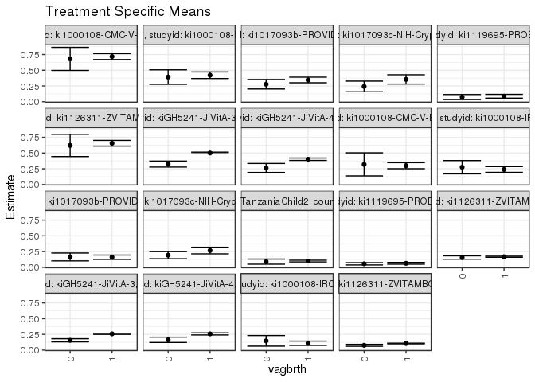

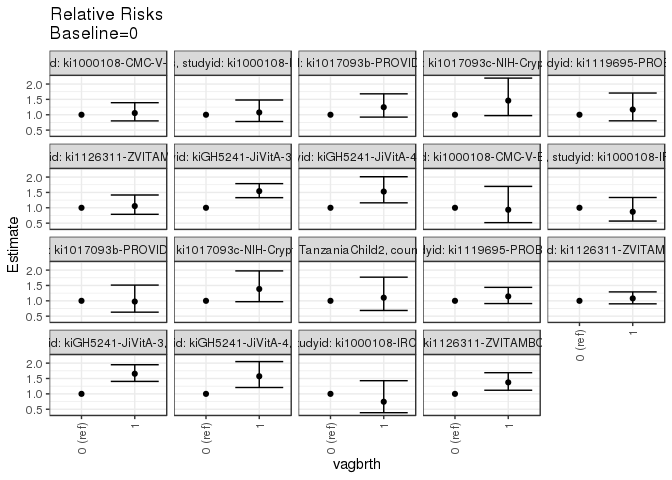

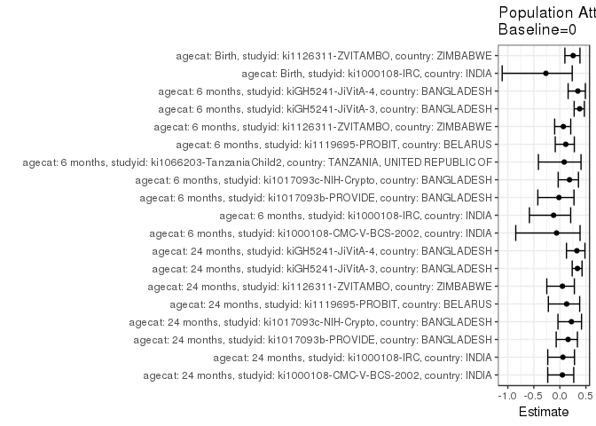

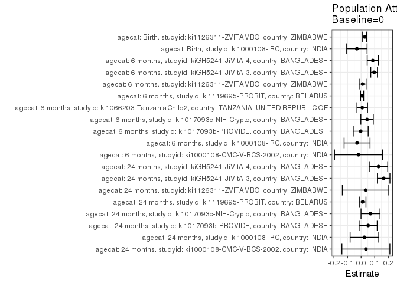

## Results Table

### Parameter: TSM

| agecat | studyid | country | intervention_level | baseline_level | estimate | ci_lower | ci_upper |
| --- | --- | --- | --- | --- | --- | --- | --- |
| Birth | ki1000108-IRC | INDIA | 0 | NA | 0.1470588 | 0.0627721 | 0.2313455 |
| Birth | ki1000108-IRC | INDIA | 1 | NA | 0.1093750 | 0.0751345 | 0.1436155 |
| Birth | ki1126311-ZVITAMBO | ZIMBABWE | 0 | NA | 0.0765921 | 0.0613006 | 0.0918836 |
| Birth | ki1126311-ZVITAMBO | ZIMBABWE | 1 | NA | 0.1052254 | 0.0998577 | 0.1105931 |
| 6 months | ki1000108-CMC-V-BCS-2002 | INDIA | 0 | NA | 0.3200000 | 0.1368964 | 0.5031036 |
| 6 months | ki1000108-CMC-V-BCS-2002 | INDIA | 1 | NA | 0.2994186 | 0.2509538 | 0.3478835 |
| 6 months | ki1000108-IRC | INDIA | 0 | NA | 0.2753623 | 0.1698337 | 0.3808910 |
| 6 months | ki1000108-IRC | INDIA | 1 | NA | 0.2396450 | 0.1940816 | 0.2852084 |
| 6 months | ki1017093b-PROVIDE | BANGLADESH | 0 | NA | 0.1641791 | 0.1014045 | 0.2269537 |
| 6 months | ki1017093b-PROVIDE | BANGLADESH | 1 | NA | 0.1603563 | 0.1263869 | 0.1943258 |
| 6 months | ki1017093c-NIH-Crypto | BANGLADESH | 0 | NA | 0.1925134 | 0.1359414 | 0.2490853 |
| 6 months | ki1017093c-NIH-Crypto | BANGLADESH | 1 | NA | 0.2666667 | 0.2138614 | 0.3194719 |
| 6 months | ki1066203-TanzaniaChild2 | TANZANIA, UNITED REPUBLIC OF | 0 | NA | 0.0899471 | 0.0491478 | 0.1307464 |
| 6 months | ki1066203-TanzaniaChild2 | TANZANIA, UNITED REPUBLIC OF | 1 | NA | 0.0991189 | 0.0853719 | 0.1128660 |
| 6 months | ki1119695-PROBIT | BELARUS | 0 | NA | 0.0555864 | 0.0376169 | 0.0735559 |
| 6 months | ki1119695-PROBIT | BELARUS | 1 | NA | 0.0636012 | 0.0497572 | 0.0774452 |
| 6 months | ki1126311-ZVITAMBO | ZIMBABWE | 0 | NA | 0.1555870 | 0.1288675 | 0.1823065 |
| 6 months | ki1126311-ZVITAMBO | ZIMBABWE | 1 | NA | 0.1677968 | 0.1593510 | 0.1762427 |
| 6 months | kiGH5241-JiVitA-3 | BANGLADESH | 0 | NA | 0.1559889 | 0.1308441 | 0.1811336 |
| 6 months | kiGH5241-JiVitA-3 | BANGLADESH | 1 | NA | 0.2581284 | 0.2497891 | 0.2664676 |
| 6 months | kiGH5241-JiVitA-4 | BANGLADESH | 0 | NA | 0.1636905 | 0.1215487 | 0.2058322 |
| 6 months | kiGH5241-JiVitA-4 | BANGLADESH | 1 | NA | 0.2575350 | 0.2405496 | 0.2745204 |
| 24 months | ki1000108-CMC-V-BCS-2002 | INDIA | 0 | NA | 0.6800000 | 0.4968984 | 0.8631016 |
| 24 months | ki1000108-CMC-V-BCS-2002 | INDIA | 1 | NA | 0.7175793 | 0.6701495 | 0.7650090 |
| 24 months | ki1000108-IRC | INDIA | 0 | NA | 0.3913043 | 0.2760088 | 0.5065999 |
| 24 months | ki1000108-IRC | INDIA | 1 | NA | 0.4205882 | 0.3680516 | 0.4731249 |
| 24 months | ki1017093b-PROVIDE | BANGLADESH | 0 | NA | 0.2773723 | 0.2023391 | 0.3524054 |
| 24 months | ki1017093b-PROVIDE | BANGLADESH | 1 | NA | 0.3454545 | 0.3009849 | 0.3899242 |
| 24 months | ki1017093c-NIH-Crypto | BANGLADESH | 0 | NA | 0.2424242 | 0.1578441 | 0.3270044 |
| 24 months | ki1017093c-NIH-Crypto | BANGLADESH | 1 | NA | 0.3540373 | 0.2800256 | 0.4280489 |
| 24 months | ki1119695-PROBIT | BELARUS | 0 | NA | 0.0741525 | 0.0343208 | 0.1139843 |
| 24 months | ki1119695-PROBIT | BELARUS | 1 | NA | 0.0867247 | 0.0569140 | 0.1165353 |
| 24 months | ki1126311-ZVITAMBO | ZIMBABWE | 0 | NA | 0.6206897 | 0.4438960 | 0.7974834 |
| 24 months | ki1126311-ZVITAMBO | ZIMBABWE | 1 | NA | 0.6555819 | 0.6101411 | 0.7010228 |
| 24 months | kiGH5241-JiVitA-3 | BANGLADESH | 0 | NA | 0.3250000 | 0.2773712 | 0.3726288 |
| 24 months | kiGH5241-JiVitA-3 | BANGLADESH | 1 | NA | 0.5007404 | 0.4874443 | 0.5140364 |
| 24 months | kiGH5241-JiVitA-4 | BANGLADESH | 0 | NA | 0.2631579 | 0.1917231 | 0.3345927 |
| 24 months | kiGH5241-JiVitA-4 | BANGLADESH | 1 | NA | 0.4022180 | 0.3830803 | 0.4213557 |

### Parameter: E(Y)

| agecat | studyid | country | intervention_level | baseline_level | estimate | ci_lower | ci_upper |
| --- | --- | --- | --- | --- | --- | --- | --- |
| Birth | ki1000108-IRC | INDIA | NA | NA | 0.1159794 | 0.0840777 | 0.1478811 |
| Birth | ki1126311-ZVITAMBO | ZIMBABWE | NA | NA | 0.1027997 | 0.0977170 | 0.1078823 |
| 6 months | ki1000108-CMC-V-BCS-2002 | INDIA | NA | NA | 0.3008130 | 0.2539566 | 0.3476694 |
| 6 months | ki1000108-IRC | INDIA | NA | NA | 0.2457002 | 0.2038248 | 0.2875757 |
| 6 months | ki1017093b-PROVIDE | BANGLADESH | NA | NA | 0.1612350 | 0.1313580 | 0.1911120 |
| 6 months | ki1017093c-NIH-Crypto | BANGLADESH | NA | NA | 0.2363239 | 0.1973320 | 0.2753157 |
| 6 months | ki1066203-TanzaniaChild2 | TANZANIA, UNITED REPUBLIC OF | NA | NA | 0.0982544 | 0.0852222 | 0.1112866 |
| 6 months | ki1119695-PROBIT | BELARUS | NA | NA | 0.0626864 | 0.0488489 | 0.0765238 |
| 6 months | ki1126311-ZVITAMBO | ZIMBABWE | NA | NA | 0.1667477 | 0.1586931 | 0.1748023 |
| 6 months | kiGH5241-JiVitA-3 | BANGLADESH | NA | NA | 0.2515539 | 0.2434271 | 0.2596807 |
| 6 months | kiGH5241-JiVitA-4 | BANGLADESH | NA | NA | 0.2497532 | 0.2336426 | 0.2658638 |
| 24 months | ki1000108-CMC-V-BCS-2002 | INDIA | NA | NA | 0.7150538 | 0.6691221 | 0.7609854 |
| 24 months | ki1000108-IRC | INDIA | NA | NA | 0.4156479 | 0.3678270 | 0.4634689 |
| 24 months | ki1017093b-PROVIDE | BANGLADESH | NA | NA | 0.3292894 | 0.2909105 | 0.3676684 |
| 24 months | ki1017093c-NIH-Crypto | BANGLADESH | NA | NA | 0.3115385 | 0.2551365 | 0.3679404 |
| 24 months | ki1119695-PROBIT | BELARUS | NA | NA | 0.0852540 | 0.0554439 | 0.1150642 |
| 24 months | ki1126311-ZVITAMBO | ZIMBABWE | NA | NA | 0.6533333 | 0.6093135 | 0.6973532 |
| 24 months | kiGH5241-JiVitA-3 | BANGLADESH | NA | NA | 0.4909133 | 0.4777756 | 0.5040511 |
| 24 months | kiGH5241-JiVitA-4 | BANGLADESH | NA | NA | 0.3910448 | 0.3723963 | 0.4096932 |

### Parameter: RR

| agecat | studyid | country | intervention_level | baseline_level | estimate | ci_lower | ci_upper |
| --- | --- | --- | --- | --- | --- | --- | --- |
| Birth | ki1000108-IRC | INDIA | 0 | 0 | 1.0000000 | 1.0000000 | 1.000000 |
| Birth | ki1000108-IRC | INDIA | 1 | 0 | 0.7437500 | 0.3870802 | 1.429068 |
| Birth | ki1126311-ZVITAMBO | ZIMBABWE | 0 | 0 | 1.0000000 | 1.0000000 | 1.000000 |
| Birth | ki1126311-ZVITAMBO | ZIMBABWE | 1 | 0 | 1.3738421 | 1.1180085 | 1.688218 |
| 6 months | ki1000108-CMC-V-BCS-2002 | INDIA | 0 | 0 | 1.0000000 | 1.0000000 | 1.000000 |
| 6 months | ki1000108-CMC-V-BCS-2002 | INDIA | 1 | 0 | 0.9356831 | 0.5162674 | 1.695832 |
| 6 months | ki1000108-IRC | INDIA | 0 | 0 | 1.0000000 | 1.0000000 | 1.000000 |
| 6 months | ki1000108-IRC | INDIA | 1 | 0 | 0.8702896 | 0.5673744 | 1.334928 |
| 6 months | ki1017093b-PROVIDE | BANGLADESH | 0 | 0 | 1.0000000 | 1.0000000 | 1.000000 |
| 6 months | ki1017093b-PROVIDE | BANGLADESH | 1 | 0 | 0.9767159 | 0.6308578 | 1.512186 |
| 6 months | ki1017093c-NIH-Crypto | BANGLADESH | 0 | 0 | 1.0000000 | 1.0000000 | 1.000000 |
| 6 months | ki1017093c-NIH-Crypto | BANGLADESH | 1 | 0 | 1.3851852 | 0.9718846 | 1.974245 |
| 6 months | ki1066203-TanzaniaChild2 | TANZANIA, UNITED REPUBLIC OF | 0 | 0 | 1.0000000 | 1.0000000 | 1.000000 |
| 6 months | ki1066203-TanzaniaChild2 | TANZANIA, UNITED REPUBLIC OF | 1 | 0 | 1.1019693 | 0.6857631 | 1.770781 |
| 6 months | ki1119695-PROBIT | BELARUS | 0 | 0 | 1.0000000 | 1.0000000 | 1.000000 |
| 6 months | ki1119695-PROBIT | BELARUS | 1 | 0 | 1.1441856 | 0.9100640 | 1.438537 |
| 6 months | ki1126311-ZVITAMBO | ZIMBABWE | 0 | 0 | 1.0000000 | 1.0000000 | 1.000000 |
| 6 months | ki1126311-ZVITAMBO | ZIMBABWE | 1 | 0 | 1.0784760 | 0.9017580 | 1.289826 |
| 6 months | kiGH5241-JiVitA-3 | BANGLADESH | 0 | 0 | 1.0000000 | 1.0000000 | 1.000000 |
| 6 months | kiGH5241-JiVitA-3 | BANGLADESH | 1 | 0 | 1.6547874 | 1.4055850 | 1.948172 |
| 6 months | kiGH5241-JiVitA-4 | BANGLADESH | 0 | 0 | 1.0000000 | 1.0000000 | 1.000000 |
| 6 months | kiGH5241-JiVitA-4 | BANGLADESH | 1 | 0 | 1.5733046 | 1.2072119 | 2.050417 |
| 24 months | ki1000108-CMC-V-BCS-2002 | INDIA | 0 | 0 | 1.0000000 | 1.0000000 | 1.000000 |
| 24 months | ki1000108-CMC-V-BCS-2002 | INDIA | 1 | 0 | 1.0552636 | 0.7997388 | 1.392431 |
| 24 months | ki1000108-IRC | INDIA | 0 | 0 | 1.0000000 | 1.0000000 | 1.000000 |
| 24 months | ki1000108-IRC | INDIA | 1 | 0 | 1.0748366 | 0.7804693 | 1.480230 |
| 24 months | ki1017093b-PROVIDE | BANGLADESH | 0 | 0 | 1.0000000 | 1.0000000 | 1.000000 |
| 24 months | ki1017093b-PROVIDE | BANGLADESH | 1 | 0 | 1.2454545 | 0.9230419 | 1.680484 |
| 24 months | ki1017093c-NIH-Crypto | BANGLADESH | 0 | 0 | 1.0000000 | 1.0000000 | 1.000000 |
| 24 months | ki1017093c-NIH-Crypto | BANGLADESH | 1 | 0 | 1.4604037 | 0.9723728 | 2.193376 |
| 24 months | ki1119695-PROBIT | BELARUS | 0 | 0 | 1.0000000 | 1.0000000 | 1.000000 |
| 24 months | ki1119695-PROBIT | BELARUS | 1 | 0 | 1.1695441 | 0.8016157 | 1.706346 |
| 24 months | ki1126311-ZVITAMBO | ZIMBABWE | 0 | 0 | 1.0000000 | 1.0000000 | 1.000000 |
| 24 months | ki1126311-ZVITAMBO | ZIMBABWE | 1 | 0 | 1.0562154 | 0.7878445 | 1.416004 |
| 24 months | kiGH5241-JiVitA-3 | BANGLADESH | 0 | 0 | 1.0000000 | 1.0000000 | 1.000000 |
| 24 months | kiGH5241-JiVitA-3 | BANGLADESH | 1 | 0 | 1.5407396 | 1.3290362 | 1.786166 |
| 24 months | kiGH5241-JiVitA-4 | BANGLADESH | 0 | 0 | 1.0000000 | 1.0000000 | 1.000000 |
| 24 months | kiGH5241-JiVitA-4 | BANGLADESH | 1 | 0 | 1.5284285 | 1.1616226 | 2.011061 |

### Parameter: PAR

| agecat | studyid | country | intervention_level | baseline_level | estimate | ci_lower | ci_upper |
| --- | --- | --- | --- | --- | --- | --- | --- |
| Birth | ki1000108-IRC | INDIA | 0 | NA | -0.0310794 | -0.1061249 | 0.0439660 |
| Birth | ki1126311-ZVITAMBO | ZIMBABWE | 0 | NA | 0.0262076 | 0.0113737 | 0.0410414 |
| 6 months | ki1000108-CMC-V-BCS-2002 | INDIA | 0 | NA | -0.0191870 | -0.1957642 | 0.1573902 |
| 6 months | ki1000108-IRC | INDIA | 0 | NA | -0.0296621 | -0.1251289 | 0.0658047 |
| 6 months | ki1017093b-PROVIDE | BANGLADESH | 0 | NA | -0.0029441 | -0.0579150 | 0.0520268 |
| 6 months | ki1017093c-NIH-Crypto | BANGLADESH | 0 | NA | 0.0438105 | -0.0020329 | 0.0896539 |
| 6 months | ki1066203-TanzaniaChild2 | TANZANIA, UNITED REPUBLIC OF | 0 | NA | 0.0083073 | -0.0306876 | 0.0473021 |
| 6 months | ki1119695-PROBIT | BELARUS | 0 | NA | 0.0070999 | -0.0041718 | 0.0183717 |
| 6 months | ki1126311-ZVITAMBO | ZIMBABWE | 0 | NA | 0.0111607 | -0.0144541 | 0.0367755 |
| 6 months | kiGH5241-JiVitA-3 | BANGLADESH | 0 | NA | 0.0955651 | 0.0710596 | 0.1200705 |
| 6 months | kiGH5241-JiVitA-4 | BANGLADESH | 0 | NA | 0.0860627 | 0.0447275 | 0.1273979 |
| 24 months | ki1000108-CMC-V-BCS-2002 | INDIA | 0 | NA | 0.0350538 | -0.1413823 | 0.2114898 |
| 24 months | ki1000108-IRC | INDIA | 0 | NA | 0.0243436 | -0.0809879 | 0.1296750 |
| 24 months | ki1017093b-PROVIDE | BANGLADESH | 0 | NA | 0.0519172 | -0.0146367 | 0.1184710 |
| 24 months | ki1017093c-NIH-Crypto | BANGLADESH | 0 | NA | 0.0691142 | -0.0007935 | 0.1390219 |
| 24 months | ki1119695-PROBIT | BELARUS | 0 | NA | 0.0111015 | -0.0134825 | 0.0356855 |
| 24 months | ki1126311-ZVITAMBO | ZIMBABWE | 0 | NA | 0.0326437 | -0.1381346 | 0.2034219 |
| 24 months | kiGH5241-JiVitA-3 | BANGLADESH | 0 | NA | 0.1659133 | 0.1198437 | 0.2119830 |
| 24 months | kiGH5241-JiVitA-4 | BANGLADESH | 0 | NA | 0.1278869 | 0.0599295 | 0.1958443 |

### Parameter: PAF

| agecat | studyid | country | intervention_level | baseline_level | estimate | ci_lower | ci_upper |
| --- | --- | --- | --- | --- | --- | --- | --- |
| Birth | ki1000108-IRC | INDIA | 0 | NA | -0.2679739 | -1.1075267 | 0.2371353 |
| Birth | ki1126311-ZVITAMBO | ZIMBABWE | 0 | NA | 0.2549383 | 0.0962734 | 0.3857468 |
| 6 months | ki1000108-CMC-V-BCS-2002 | INDIA | 0 | NA | -0.0637838 | -0.8471227 | 0.3873521 |
| 6 months | ki1000108-IRC | INDIA | 0 | NA | -0.1207246 | -0.5849288 | 0.2075204 |
| 6 months | ki1017093b-PROVIDE | BANGLADESH | 0 | NA | -0.0182598 | -0.4232000 | 0.2714636 |
| 6 months | ki1017093c-NIH-Crypto | BANGLADESH | 0 | NA | 0.1853832 | -0.0321265 | 0.3570551 |
| 6 months | ki1066203-TanzaniaChild2 | TANZANIA, UNITED REPUBLIC OF | 0 | NA | 0.0845486 | -0.4120665 | 0.4065072 |
| 6 months | ki1119695-PROBIT | BELARUS | 0 | NA | 0.1132613 | -0.0886262 | 0.2777084 |
| 6 months | ki1126311-ZVITAMBO | ZIMBABWE | 0 | NA | 0.0669317 | -0.1000260 | 0.2085492 |
| 6 months | kiGH5241-JiVitA-3 | BANGLADESH | 0 | NA | 0.3798989 | 0.2747464 | 0.4698056 |
| 6 months | kiGH5241-JiVitA-4 | BANGLADESH | 0 | NA | 0.3445911 | 0.1585313 | 0.4895106 |
| 24 months | ki1000108-CMC-V-BCS-2002 | INDIA | 0 | NA | 0.0490226 | -0.2327896 | 0.2664133 |
| 24 months | ki1000108-IRC | INDIA | 0 | NA | 0.0585678 | -0.2322722 | 0.2807639 |
| 24 months | ki1017093b-PROVIDE | BANGLADESH | 0 | NA | 0.1576642 | -0.0705752 | 0.3372445 |
| 24 months | ki1017093c-NIH-Crypto | BANGLADESH | 0 | NA | 0.2218481 | -0.0368282 | 0.4159877 |
| 24 months | ki1119695-PROBIT | BELARUS | 0 | NA | 0.1302165 | -0.2206863 | 0.3802476 |
| 24 months | ki1126311-ZVITAMBO | ZIMBABWE | 0 | NA | 0.0499648 | -0.2510026 | 0.2785252 |
| 24 months | kiGH5241-JiVitA-3 | BANGLADESH | 0 | NA | 0.3379687 | 0.2368731 | 0.4256716 |
| 24 months | kiGH5241-JiVitA-4 | BANGLADESH | 0 | NA | 0.3270390 | 0.1267624 | 0.4813822 |